# Joonised paketiga ggplot2

# Mis on ggplot2?

*ggplot2* on populaarne R-i pakett, mis võimaldab suhteliselt vähese vaevaga joonistada ilusaid graafikuid. Kuna joonised on üles ehitatud kiht kihi haaval, on tegu väga paindliku tööriistaga, sest ühel graafikul saab kombineerida erinevaid elemente.

Suurepärane ülevaate paketi võimalustest annab **ggplot2 dokumentatsioon** http://docs.ggplot2.org/current/.

*ggplot2* autoriks on [Hadley Wickham](http://had.co.nz/). Pakett toetub nn graafikute grammatikale (*Grammar of Graphics*), mille avaldas Leland Wilkinson 2005. aastal. Selle grammatika eesmärk on kirjeldada, mida õieti kujutab endast üks graafik. Nii nagu tavakeeles defineerib grammatika sõnaliigid, mille kombineerimisel saame tekitada suvalisi lauseid, defineerib analoogiliselt graafikute grammatika sellised põhikomponendid, mille kombineerimisel on võimalik tekitada suvalisi graafikuid. Hadley on kirjutanud järgnevat:

> In brief, the grammar tells us that a statistical graphic is a mapping from data to aesthetic attributes (colour, shape, size) of geometric objects (points, lines, bars).

# Joonised funktsiooniga ggplot

Joonise tegemiseks tuleb alustada `ggplot` objekti konstrueerimisest. Üks võimalus on seda teha järgnevalt

```r
install.packages('ggplot2')
library(ggplot2)

ggplot(andmed, aes(x = tunnus1, y = tunnus2))
```

kus esimese argumendina on ette antud andmestik ning teise argumendina *aesthetic mapping*. Seejuures `aes()` argumendid peavad olema ette antud andmestiku veergude nimed.

Praeguseks hetkeks pole veel võimalik joonist vaadata, sest me pole joonisele ühtegi kihti lisanud (st me pole spetsifitseerinud, milliseid elemente sooviksime joonisel näha - antud *x, y* koordinaadid oleks võimalik tähistada nii punktidega, tulpadega, ühendada joontega jne). Näiteks punktide joonistamiseks peaksime lisama joonisele punktide kihi käsuga `geom_point()`.

Järgnevalt tutvume *ggplot2* võimalustega näidete abil, mis põhinevad meditsiiniüliõpilaste andmestikul:

```r
# lae andmestik "students"
load(url("https://github.com/Rkursus/deltax/raw/master/data/students.RData"))

# vaatame andmestiku päist
head(students)
```

```
##   age gender family_status sport smoking beer wine vodka    health virus
## 1  22 Female             3     1       4  1-4    3     2       bad     1
## 2  21   Male             1     4       2    0    1     1 very good     4
## 3  20 Female             1     2       1  0-1    2     2      good     2
## 4  19 Female             1     2       1  0-1    2     2  moderate     2
## 5  19 Female             1     3       1  0-1    3     1      good     3
## 6  19 Female             1     1       1    0    2     1      good     1
##   ambulance medical_care height weight SVR DVR
## 1         0            1    164     52  NA  NA
## 2         1            0    181     88  NA  NA
## 3         0            0    172     80  NA  NA
## 4         0            1    164     47  NA  NA
## 5         0            0    168     61  NA  NA
## 6         0            0    165     51 110  70
```

## geom_point()

Hajuvusdiagrammi (*scatterplot*) tegemiseks

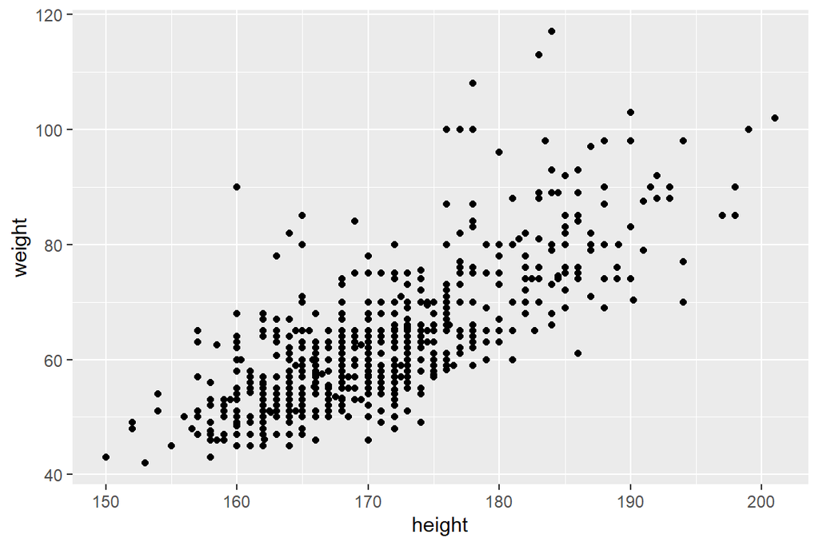

```r
ggplot(students, aes(x = height, y = weight)) + geom_point()
```

millele saame ka värvi lisada `colour = tunnuse_nimi` (võime `colour` asemel kasutada ka `color` või `col`)

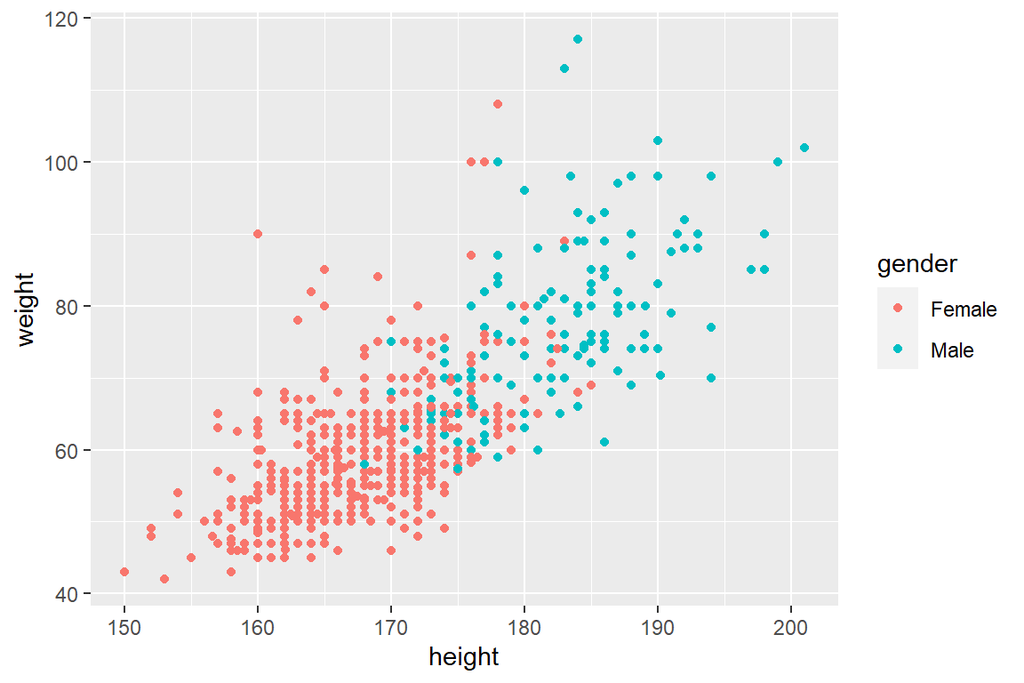

```r
ggplot(students, aes(x = height, y = weight, colour = gender)) + geom_point()
```

#### Mida teeb `aes()`?

Funktsioon `aes()` (lühend sõnast *aesthetics*) koostab seosed tunnuste ja joonise dimensioonide vahel. Automaatselt otsitakse tunnuste nimesid juurde lisatud andmestikust. Pärast `aes` rakendamist (*with variables mapped into aesthetic space*) teab funktsioon `ggplot()`, et

- *x* koordinaadiks on *height*,
- *y* koordinaadiks on *weight*,
- värvi näitab *gender*,

nagu me ise spetsifitseerisime. Saame anda ette tunnuseid veel dimensioonidele `shape`, `fill`, `linetype`, `weight` jpm.

## facet_grid() ja facet_wrap()

Näiteks tunnuse `beer` põhjal saame oma joonise jagada alamjoonisteks (tahkudeks) järgnevalt

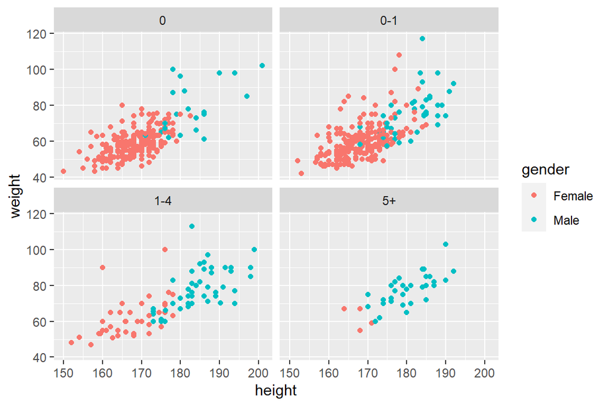

```r
ggplot(students, aes(x = height, y = weight, colour = gender)) +
  geom_point() +
  facet_wrap(~ beer)
```

## geom_histogram()

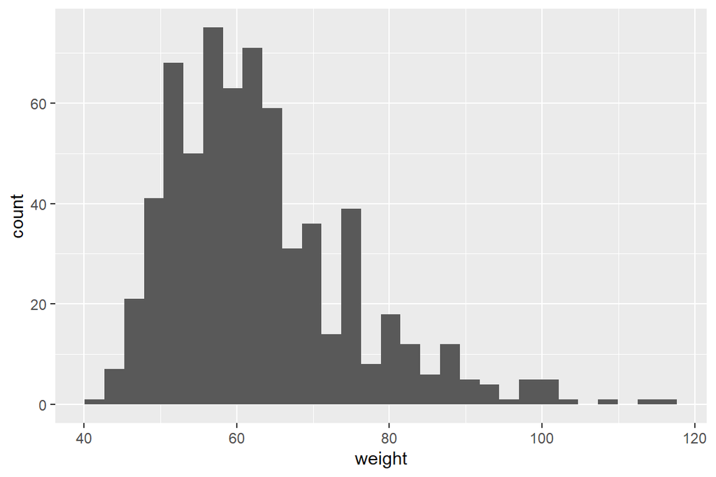

```r
ggplot(students, aes(x = weight)) + geom_histogram()
```

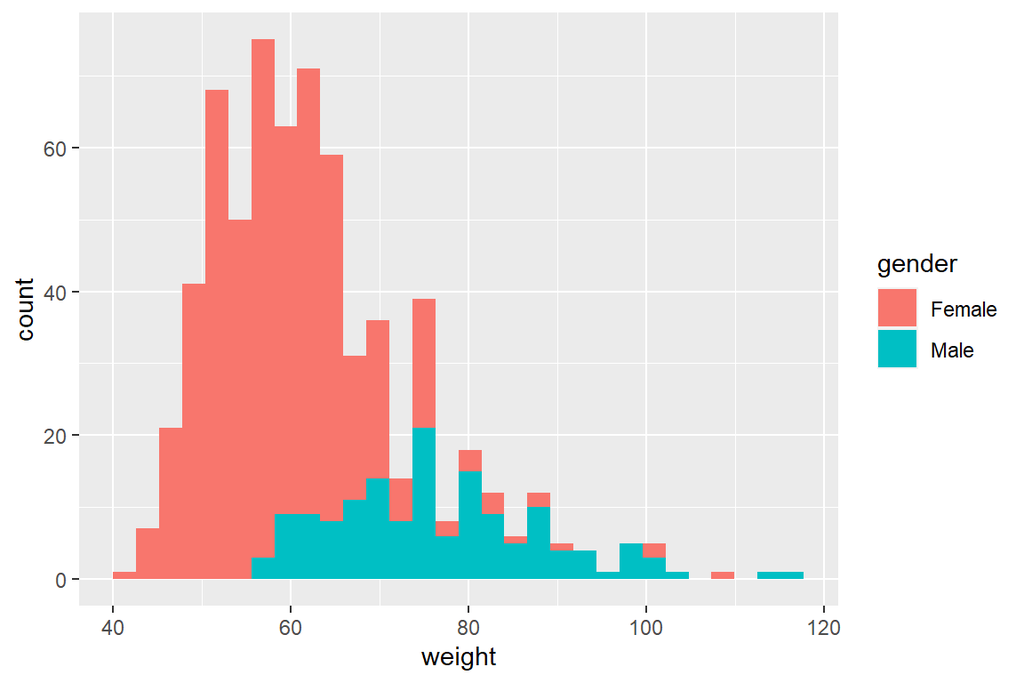

```r
# Saame histogrammi tulpasid värvida soo järgi
ggplot(students, aes(x = weight, fill=gender)) + geom_histogram()
```

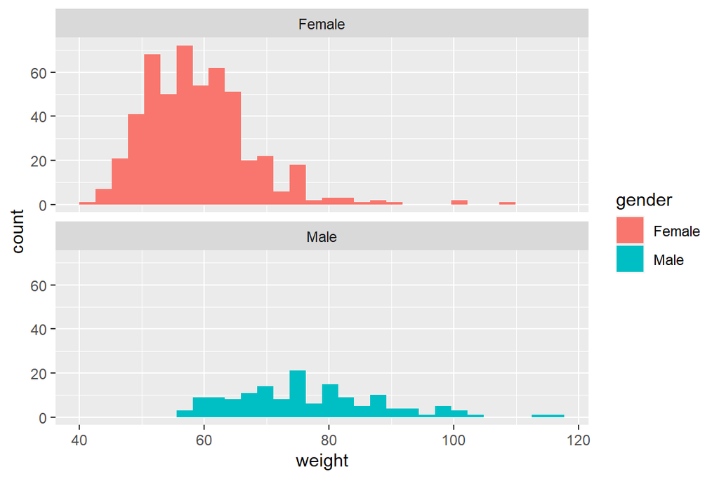

```r
# Või jagada histogramm tahkudeks soo järgi, üksteise alla
ggplot(students, aes(x = weight, fill=gender)) + geom_histogram() +
  facet_wrap(~ gender, ncol=1)
```

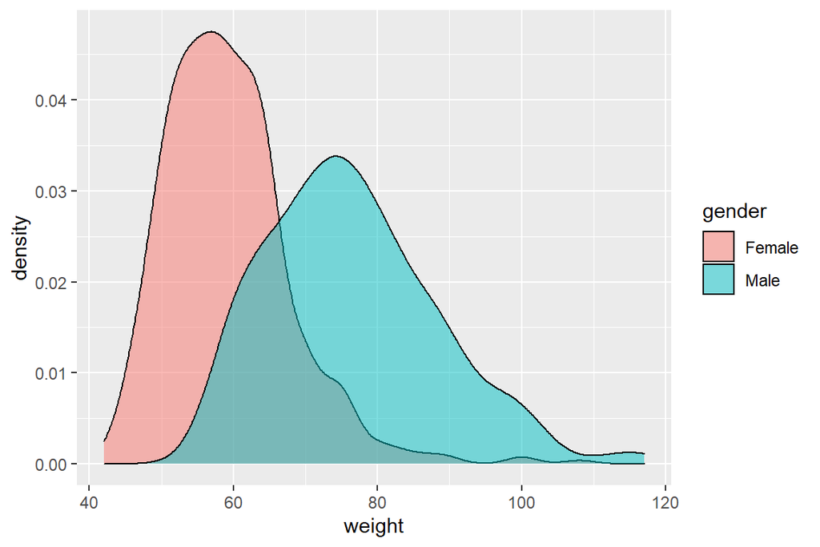

```r
# Mitteparameetriline tiheduse hinnang
ggplot(students, aes(x = weight, fill=gender)) +
  geom_density(alpha=0.5)
```

## geom_boxplot() ja geom_jitter()

Väärtuste hajuvusest ja jaotusest annavad aimu järgmised võimalused:

```r
ggplot(students, aes(x = beer, y = weight)) + geom_boxplot()
ggplot(students, aes(x = beer, y = weight)) + geom_jitter()
```

[output not shown]

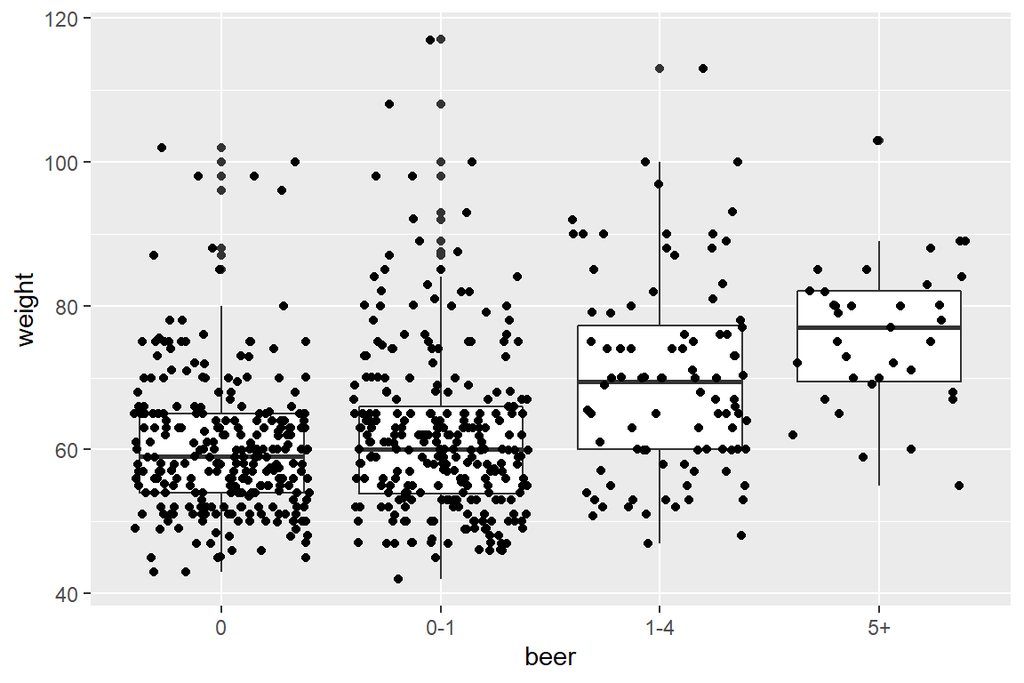

```r
# informatiivse joonise saame kahe eelneva kihi (boxploti ja punktide) kombineerimisel
ggplot(students, aes(x = beer, y = weight)) +
  geom_boxplot() + geom_jitter()
```

## stat_smooth()

Saame lisada näiteks regressioonisirge iga grupi jaoks

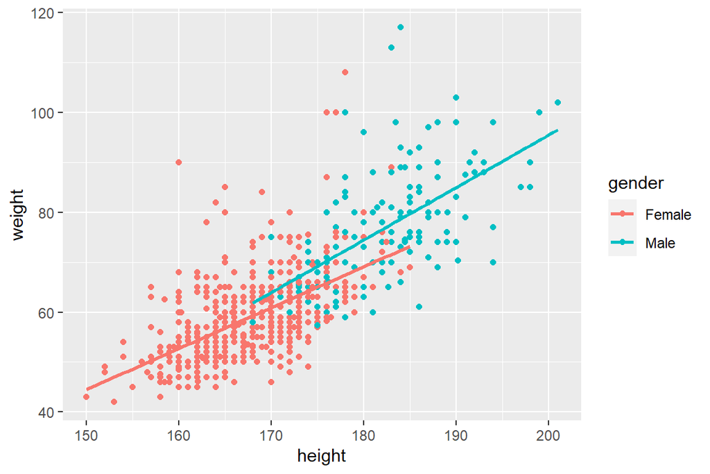

```r
ggplot(students, aes(x = height, y = weight, colour=gender)) +
  geom_point() + stat_smooth(method="lm", se=FALSE)
```